# A Data Story on ‘Love’ and ‘Death’

2023-01-27

### Name: Xinyu Zhu

### Uni: xz3136

### Basic Information:

- This project is a blog of an exploratory data analysis (EDA) of philosophy texts.
- The dataset is a corpus of more than 360000 sentences taken from 51 texts spanning the history of philosophy. You can read more on https://www.kaggle.com/datasets/kouroshalizadeh/history-of-philosophy?resource=download.

[figure not shown]

Below is the environment setting of this R notebook.

```
##                _
## platform       x86_64-apple-darwin17.0
## arch           x86_64
## os             darwin17.0
## system         x86_64, darwin17.0
## status
## major          4
## minor          2.1
## year           2022
## month          06
## day            23
## svn rev        82513
## language       R
## version.string R version 4.2.1 (2022-06-23)
## nickname       Funny-Looking Kid
```

For this data-set, I think it would be good to split it into subsets according to different schools. Since there are too many authors ans there are authors under the same school, so sub-setting by school is better than doing by authors. So i did that and named each subset by the school name. For example, “plato” is a data-frame with data only under the school of Plato.

Then, I create a data-frame with four columns: School, num_love (number of times “love” is being mentioned across all the sentences in the corresponding school), num_death (number of times “death” is being mentioned across all the sentences in the corresponding school), and total_sentences (number of total sentences in that school).

However, the data-frame is not indicative enough to look at. Since the number of total sentences in each school is different, only looking at the number of times that “love” or “death” is being mentioned is not precise. So I added three more columns, percent_love (the ratio of num_love and total_sentences), percent_death (the ratio of num_death and total_sentences), and percent_diff (the absolute value of the difference between percent_love and percent_death). Right now, the data is more indicative, but it is still hard to browse the numbers one by one for discoveries. So the next step is to visualize the data.

First, I did two bar-plots to visualize “love” and “death” separately. I found that authors under the school of “Feminism” mentioned “love” for the highest percent. And authors under the school of “Stoicism” mentioned “death” for the highest percent.

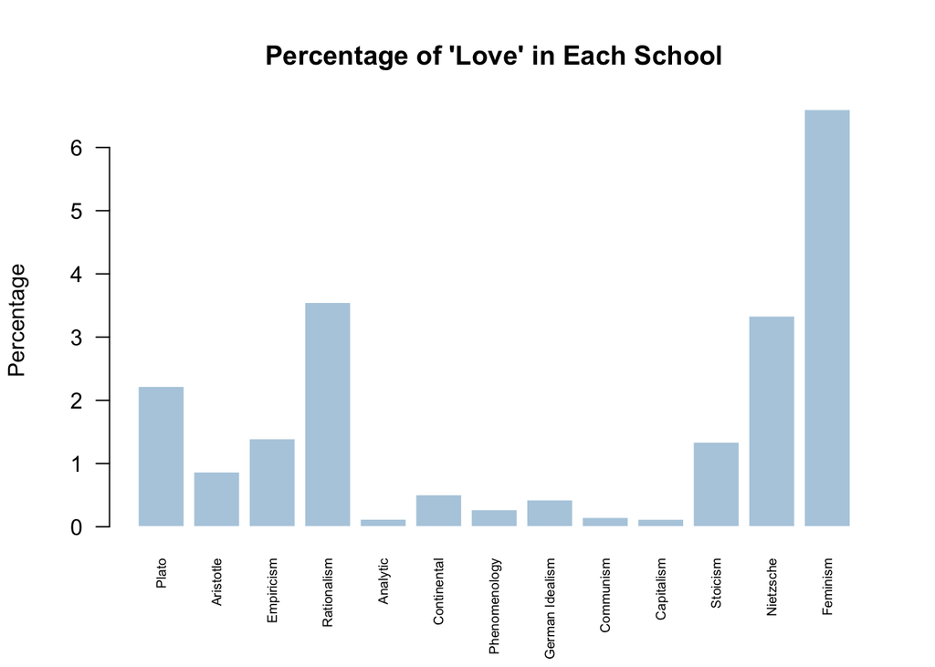

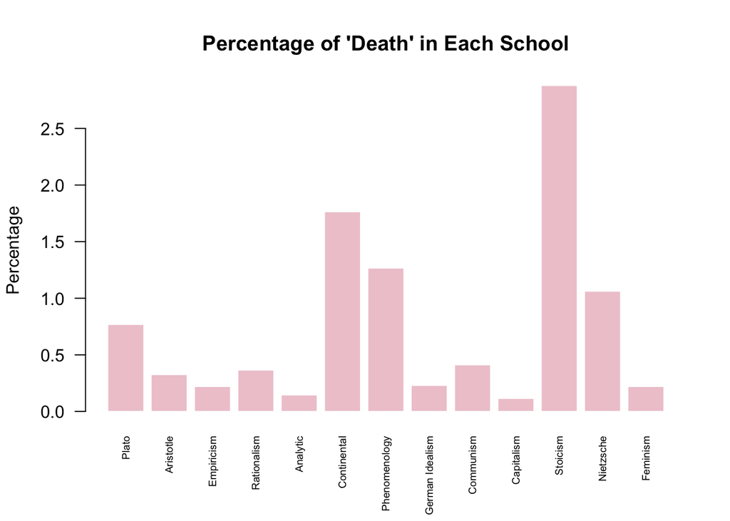

Then I thought that it would be better if I made another bar-plot with both “love” and “death” side by side for each school. So I made a subset of the previous data-frame by keeping only three columns, Schools, percent_love and percent_death, so that I could do a grouped bar-plot to better visualize the data. By looking at the grouped bar-plot, we could see that “Feminism” has the largest difference of the times mentioning “love” and “death”, and the school with the least difference is “Capitalism”.

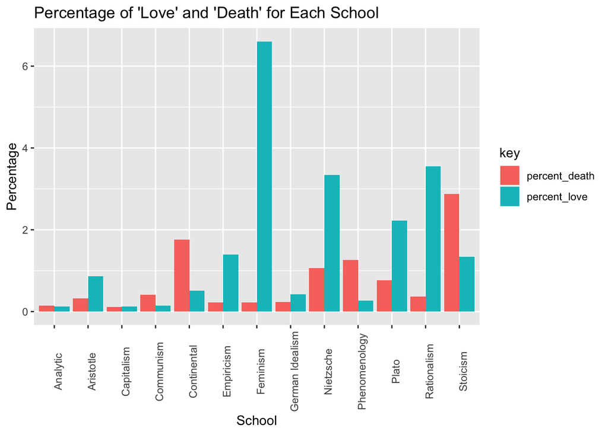

In order to be certain, I created another bar-plot to visualize the difference. And also used built-in functions to make sure that “Capitalism” has the least difference.

I could not generate precise explanations for why feminists mention “love” for the highest percentage, because that would be too subjective. But I guess capitalism focuses much less on “love” and “death” since it is more about economy, demand and property.

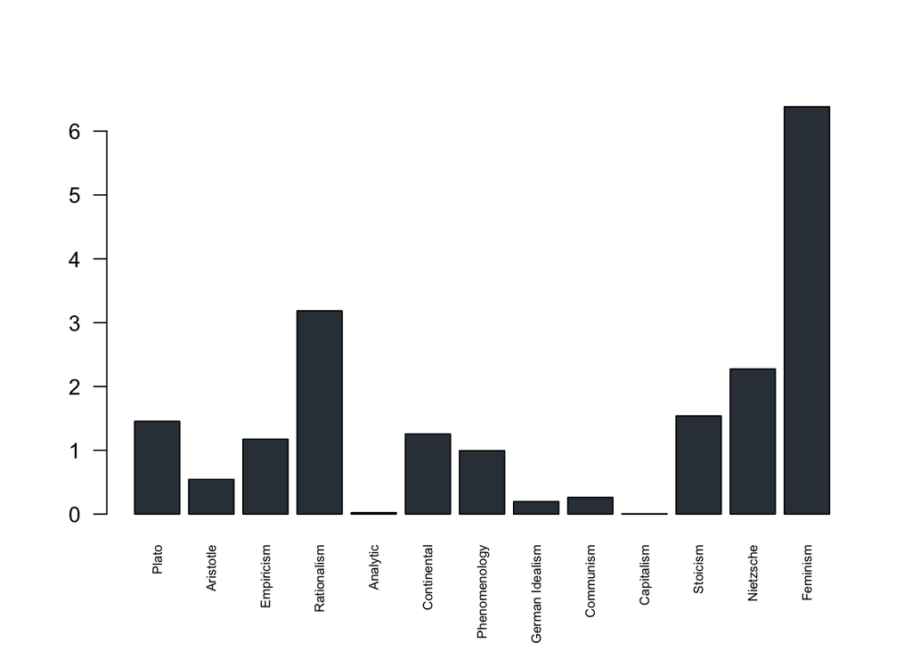

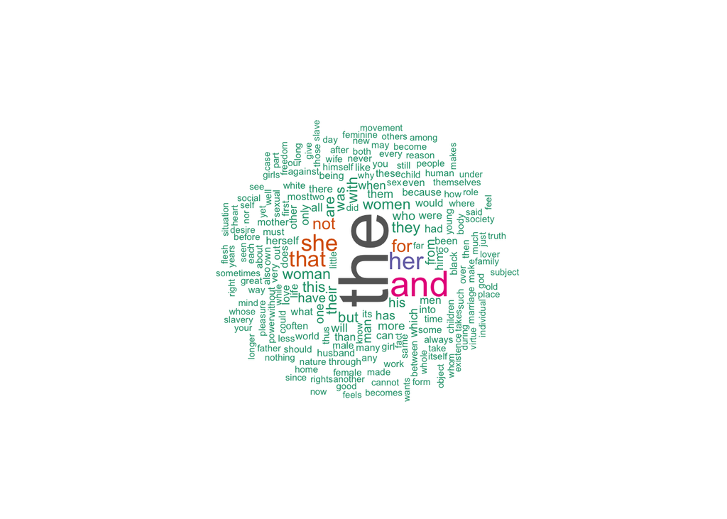

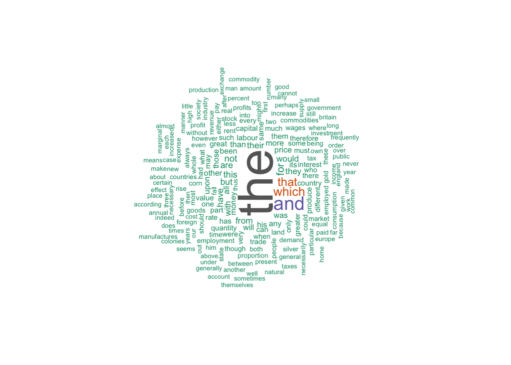

In conclusion, the results matched what I expected from the data, which is that there were clear differences between the usage of word across different philosophical schools.